# Respuestas a la tarea 4

# Pregunta 1

Considere los datos en *MunichRent.rda*. Estos archivos contienen información sobre rentas en la ciudad de Munich, **rent**. Se desea modelar la renta en función de la antiguedad de los edificios en renta, controlando por el área, **area**. También se desea controlar por el tipo de baño y cocina que tiene el edificio, usando efectos fijos de las variables **bath** y **kitchen**. La variable **yearc** indica cuándo fue construido el edificio. Para leer los datos basta con ejecutar lo siguiente:

```r
load("./MunichRent.rda")
```

1. [10 puntos] Estime la densidad Kernel de las rentas por metro cuadrado, **rentsqm**, usando un Kernel gaussiano. Use el estimador *plug-in* de Silverman para estimar el ancho de ventana óptimo.

   *Simplemente seguimos el procedimiento que vimos en clase para obtener $h$*.

   ```r
   load("C:/Users/rojas/Dropbox/sitios_git/ECNII2020/tareas/MunichRent.rda")

   rentsqm.sd <- sd(MunichRent$rentsqm)
   rentsqm.iqr.adj <- IQR(MunichRent$rentsqm)/1.349
   rentsqm.N <- nrow(MunichRent)
   constante <- 1.3643
   ajuste <- min(rentsqm.sd,rentsqm.iqr.adj)

   delta <- 0.7764
   h <- constante*delta*ajuste*rentsqm.N^(-0.2)
   ```

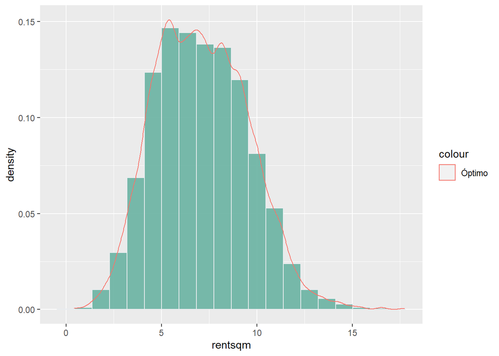

2. [10 puntos] Estime por MCO la relación entre el la renta, **rent** y la antiguedad del edificio, controlando por **area** y efectos fijos de **bath** y **kitchen**. Estime la misma relación, pero con una regresión mediana. Interprete los coeficientes sobre la antiguedad en ambos casos.

   *Primero por MCO obtenemos una relación positiva entre la renta y el área y una relación negativa entre la renta y la antiguedad, como era de esperarse. Ambos coeficientes estimados son estadísticamente significativos.*

   ```r
   MunichRent <- MunichRent %>%
     mutate(antiguedad=2020-yearc)

   #Por MCO
   summary(r.mco <- lm(rent  ~ area+antiguedad+factor(bath)+factor(kitchen),
                   data=MunichRent))
   ```

   ```
   ##
   ## Call:
   ## lm(formula = rent ~ area + antiguedad + factor(bath) + factor(kitchen),
   ##     data = MunichRent)
   ##
   ## Residuals:
   ##     Min      1Q  Median      3Q     Max
   ## -714.67  -92.43   -9.46   82.65 1082.53
   ##
   ## Coefficients:
   ##                         Estimate Std. Error t value Pr(>|t|)
   ## (Intercept)             251.0194    10.0231  25.044  < 2e-16 ***
   ## area                      5.1186     0.1187  43.113  < 2e-16 ***
   ## antiguedad               -2.2780     0.1238 -18.399  < 2e-16 ***
   ## factor(bath)superior     68.5383    11.3822   6.022 1.93e-09 ***
   ## factor(kitchen)superior 103.5779    13.2449   7.820 7.19e-15 ***
   ## ---
   ## Signif. codes:  0 '***' 0.001 '**' 0.01 '*' 0.05 '.' 0.1 ' ' 1
   ##
   ## Residual standard error: 146.9 on 3077 degrees of freedom
   ## Multiple R-squared:  0.4367, Adjusted R-squared:  0.4359
   ## F-statistic: 596.3 on 4 and 3077 DF,  p-value: < 2.2e-16
   ```

   *Ahora realizamos un modelo LAD*:

   ```r
   summary(r.q50 <- rq(rent  ~ area+antiguedad+factor(bath)+factor(kitchen),
                   data=MunichRent,
                   tau=0.5))
   ```

   ```
   ##
   ## Call: rq(formula = rent ~ area + antiguedad + factor(bath) + factor(kitchen),
   ##     tau = 0.5, data = MunichRent)
   ##
   ## tau: [1] 0.5
   ##
   ## Coefficients:
   ##                         Value     Std. Error t value   Pr(>|t|)
   ## (Intercept)             289.60336  11.42754   25.34259   0.00000
   ## area                      4.77219   0.14862   32.10897   0.00000
   ## antiguedad               -2.72454   0.14844  -18.35508   0.00000
   ## factor(bath)superior     60.86279  23.86640    2.55015   0.01082
   ## factor(kitchen)superior 106.22395  16.40390    6.47553   0.00000
   ```

   *Los coeficientes estimados son de una magnitud similar a los de MCO.*
3. [10 puntos] Estime ahora una regresión cuantil para cada uno de los deciles de la distribución de la renta y represente en una gráfica los coeficientes por regresión cuantil junto con el coeficiente de MCO para las variables del área y la antiguedad. ¿Concluye que vale la pena modelar la relación de las rentas en función del área y la antiguedad usando regresión cuantil?

   *Regresión cuantil para cada decil:*

   ```r
   r.q1_9 <- rq(rent  ~ area+antiguedad+factor(bath)+factor(kitchen),
                   data=MunichRent,
                   tau= 1:9/10)
   ```

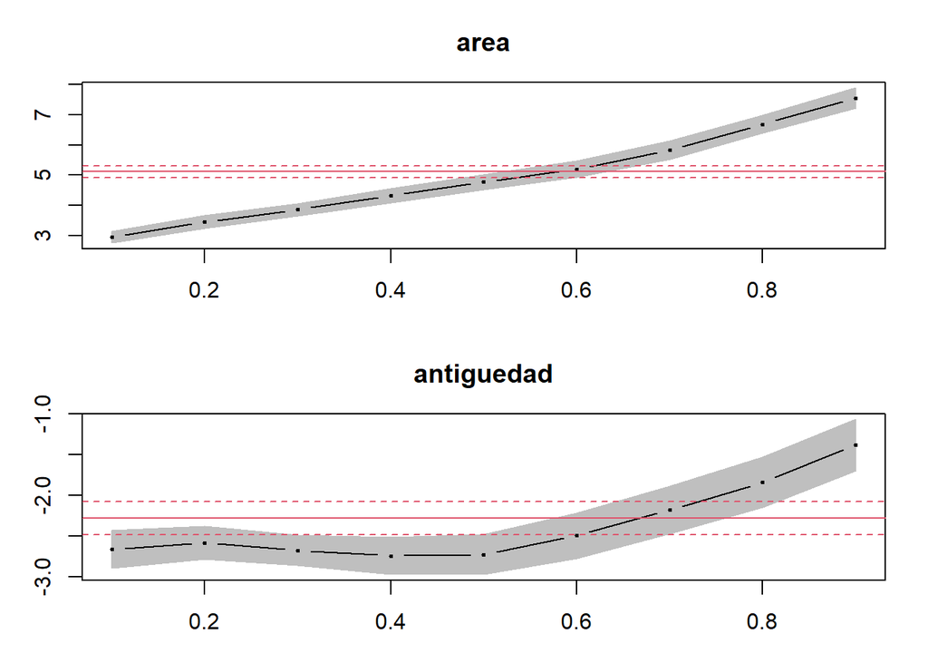

   ```r
   plot(summary(r.q1_9), parm=c("area","antiguedad"))
   ```

   *Los efectos de la antiguedad en la distribución de precios son no lineales. Los efectos en los cuantiles superiores crecen más rápido con la antiguedad. Quizás esto sugiera una preferencia por edificios viejos. La regresión cuantil sí fue útil para revelar esta característica.*

# Pregunta 2

Considere los datos en *crimen_nc.csv*. Estos son datos anuales de 1981 a 1987 sobre crimen del estado de Carolina del Norte en Estados Unidos. Se desea modelar el log de la tasa de crimen, **lcrmrte**, en función del log de la probabilidad de arresto (**lprbarr**) y del log del número de policías per cápita (**lpolpc**).

Se propone incluir como controles la probabilidad de sentencia (**lnprbconv**), la probabilidad de ir a prisión (**lprbpris**), el tiempo promedio de sentencia (**lavgsen**), la densidad de población (**ldensity**), el porcentaje de población joven (**lpctmle**), el porcentaje de la población no blanca (**lpctmin**), los salarios semanales en la construcción (**lwcon**), el transporte (**lwtuc**), el comercio (**lwtrd**), las finanzas (**lwfir**), los servicios (**lwser**), la manufactura (**lwmfg**) y los gobierno federal, estatal y local (**lwfed**, **lwsta** y **lwloc**). Además, se propone controlar por una dummy que indica una ciudad grande (**smsa**) y dummies regionales (**region**), así como efectos fijos por condado y por año.

1. [10 puntos] Estime un modelo de efectos fijos con los regresores descritos anteriormente. Interprete los coeficientes sobre el log de la probabilidad de arresto y el log del número de policías per cápita.

   *Modelo de efetos fijos. Existe una relación negativa entre los arrestos y la tasa de crimen. Sin embargo, parece haber una relación positiva entre el número de policías y la tasa de crimen.*

   ```r
   data.crime<-read_csv("./crimen_nc.csv",
                 locale = locale(encoding = "latin1"))


   cr.within <- plm(lcrmrte ~ lprbarr + lpolpc +
                  lprbconv + lprbpris + lavgsen +
                  ldensity + lpctymle + lpctmin +
                  lwcon + lwtuc + lwtrd + lwfir +
                  lwser + lwmfg + lwfed + lwsta +
                  lwloc + region + smsa + factor(year),
                data = data.crime,
                model = "within",
                index = c("county","year"))
   summary(cr.within)
   ```

   ```
   ## Oneway (individual) effect Within Model
   ##
   ## Call:
   ## plm(formula = lcrmrte ~ lprbarr + lpolpc + lprbconv + lprbpris +
   ##     lavgsen + ldensity + lpctymle + lpctmin + lwcon + lwtuc +
   ##     lwtrd + lwfir + lwser + lwmfg + lwfed + lwsta + lwloc + region +
   ##     smsa + factor(year), data = data.crime, model = "within",
   ##     index = c("county", "year"))
   ##
   ## Balanced Panel: n = 90, T = 7, N = 630
   ##
   ## Residuals:
   ##       Min.    1st Qu.     Median    3rd Qu.       Max.
   ## -0.5581649 -0.0650179 -0.0018191  0.0697977  0.5247016
   ##
   ## Coefficients:
   ##                  Estimate Std. Error  t-value  Pr(>|t|)
   ## lprbarr        -0.3548297  0.0322049 -11.0179 < 2.2e-16 ***
   ## lpolpc          0.4131620  0.0266232  15.5189 < 2.2e-16 ***
   ## lprbconv       -0.2815691  0.0211376 -13.3208 < 2.2e-16 ***
   ## lprbpris       -0.1731041  0.0323027  -5.3588 1.263e-07 ***
   ## lavgsen        -0.0024530  0.0261190  -0.0939  0.925213
   ## ldensity        0.4143897  0.2825413   1.4667  0.143078
   ## lpctymle        0.6267536  0.3636058   1.7237  0.085356 .
   ## lwcon          -0.0377918  0.0390756  -0.9671  0.333923
   ## lwtuc           0.0455253  0.0190115   2.3946  0.016992 *
   ## lwtrd          -0.0205017  0.0404789  -0.5065  0.612737
   ## lwfir          -0.0038992  0.0282572  -0.1380  0.890303
   ## lwser           0.0088771  0.0191314   0.4640  0.642836
   ## lwmfg          -0.3598524  0.1118352  -3.2177  0.001373 **
   ## lwfed          -0.3093168  0.1761642  -1.7558  0.079706 .
   ## lwsta           0.0528856  0.1135305   0.4658  0.641535
   ## lwloc           0.1816065  0.1176542   1.5436  0.123305
   ## factor(year)82  0.0226837  0.0259310   0.8748  0.382102
   ## factor(year)83 -0.0405141  0.0357204  -1.1342  0.257235
   ## factor(year)84 -0.0434463  0.0464791  -0.9347  0.350354
   ## factor(year)85 -0.0165510  0.0634444  -0.2609  0.794294
   ## factor(year)86  0.0347737  0.0781032   0.4452  0.656342
   ## factor(year)87  0.0997564  0.0930562   1.0720  0.284219
   ## ---
   ## Signif. codes:  0 '***' 0.001 '**' 0.01 '*' 0.05 '.' 0.1 ' ' 1
   ##
   ## Total Sum of Squares:    17.991
   ## Residual Sum of Squares: 9.6545
   ## R-Squared:      0.46336
   ## Adj. R-Squared: 0.34837
   ## F-statistic: 20.3305 on 22 and 518 DF, p-value: < 2.22e-16
   ```

2. [10 puntos] Existe la preocupación de que la variable que indica el número de policías es endógena. Se propone usar como instrumento el porcentaje de los crímenes que son cara a cara (robos, violación, asaltos) con respecto al resto (**lmix**) pues se argumenta que estos crímenes facilitan la identificación del criminal. Se propone usar también como instrumento el ingreso per cápita por impuestos (**ltaxpc**) bajo el argumento de que los condados con preferencia por hacer valer la ley tendrán mayores ingresos para financiar la policía. Estime el modelo de efectos fijos tomando en cuenta la endogeneidad e incluyendo las dos variables propuestas como instrumentos. ¿Cómo cambian sus resultados sobre el efecto del número de policías en el crimen?

   ```r
   cr.within.iv1 <- plm(lcrmrte ~ lprbarr + lpolpc +
                      lprbconv + lprbpris + lavgsen +
                      ldensity + lpctymle + lpctmin +
                      lwcon + lwtuc + lwtrd + lwfir +
                      lwser + lwmfg + lwfed + lwsta +
                      lwloc + region + smsa + factor(year) |
                      . -lprbarr  + lmix + ltaxpc,
                data = data.crime,
                model = "within",
                index = c("county","year"))
   summary(cr.within.iv1)
   ```

   ```
   ## Oneway (individual) effect Within Model
   ## Instrumental variable estimation
   ##
   ## Call:
   ## plm(formula = lcrmrte ~ lprbarr + lpolpc + lprbconv + lprbpris +
   ##     lavgsen + ldensity + lpctymle + lpctmin + lwcon + lwtuc +
   ##     lwtrd + lwfir + lwser + lwmfg + lwfed + lwsta + lwloc + region +
   ##     smsa + factor(year) | . - lprbarr + lmix + ltaxpc, data = data.crime,
   ##     model = "within", index = c("county", "year"))
   ##
   ## Balanced Panel: n = 90, T = 7, N = 630
   ##
   ## Residuals:
   ##       Min.    1st Qu.     Median    3rd Qu.       Max.
   ## -0.5591411 -0.0644737 -0.0014077  0.0699662  0.5306695
   ##
   ## Coefficients:
   ##                  Estimate Std. Error z-value  Pr(>|z|)
   ## lprbarr        -0.3456567  0.1409189 -2.4529  0.014172 *
   ## lpolpc          0.4106995  0.0454446  9.0374 < 2.2e-16 ***
   ## lprbconv       -0.2778395  0.0596500 -4.6578 3.196e-06 ***
   ## lprbpris       -0.1703735  0.0520718 -3.2719  0.001068 **
   ## lavgsen        -0.0025191  0.0261397 -0.0964  0.923227
   ## ldensity        0.4215497  0.3021739  1.3951  0.162999
   ## lpctymle        0.6212637  0.3727885  1.6665  0.095608 .
   ## lwcon          -0.0380570  0.0392795 -0.9689  0.332606
   ## lwtuc           0.0457219  0.0192391  2.3765  0.017477 *
   ## lwtrd          -0.0205798  0.0404989 -0.5082  0.611344
   ## lwfir          -0.0037104  0.0284000 -0.1306  0.896053
   ## lwser           0.0090953  0.0194091  0.4686  0.639348
   ## lwmfg          -0.3603233  0.1120655 -3.2153  0.001303 **
   ## lwfed          -0.3081783  0.1769990 -1.7411  0.081661 .
   ## lwsta           0.0544305  0.1158667  0.4698  0.638521
   ## lwloc           0.1803547  0.1191435  1.5138  0.130087
   ## factor(year)82  0.0220994  0.0273658  0.8076  0.419346
   ## factor(year)83 -0.0412876  0.0375496 -1.0995  0.271529
   ## factor(year)84 -0.0447149  0.0502058 -0.8906  0.373127
   ## factor(year)85 -0.0179731  0.0669196 -0.2686  0.788254
   ## factor(year)86  0.0337912  0.0794794  0.4252  0.670722
   ## factor(year)87  0.0989467  0.0938481  1.0543  0.291733
   ## ---
   ## Signif. codes:  0 '***' 0.001 '**' 0.01 '*' 0.05 '.' 0.1 ' ' 1
   ##
   ## Total Sum of Squares:    17.991
   ## Residual Sum of Squares: 9.656
   ## R-Squared:      0.4633
   ## Adj. R-Squared: 0.34829
   ## Chisq: 331.842 on 22 DF, p-value: < 2.22e-16
   ```

3. [10 puntos] Se sospecha que la probabilidad de ser arrestado es también endógena. Use los mismos instrumentos que en la parte c. para estimar el modelo de efectos fijos con dos variables endógenas. ¿Cómo cambian sus conclusiones respecto a número de policías y la probabilidad de ser arrestado con respecto a la parte a.?

   *Ahora el modelo exactamente identificado:*

   ```r
   cr.within.iv2 <- plm(lcrmrte ~ lprbarr + lpolpc +
                      lprbconv + lprbpris + lavgsen +
                      ldensity + lpctymle + lpctmin +
                      lwcon + lwtuc + lwtrd + lwfir +
                      lwser + lwmfg + lwfed + lwsta +
                      lwloc + region + smsa + factor(year) |                       lmix + ltaxpc + lprbarr +
                      . -lprbarr - lpolpc + lmix + ltaxpc,
                    data = data.crime,
                    model = "within",
                    index = c("county","year"))
   summary(cr.within.iv2)
   ```

   ```
   ## Oneway (individual) effect Within Model
   ## Instrumental variable estimation
   ##
   ## Call:
   ## plm(formula = lcrmrte ~ lprbarr + lpolpc + lprbconv + lprbpris +
   ##     lavgsen + ldensity + lpctymle + lpctmin + lwcon + lwtuc +
   ##     lwtrd + lwfir + lwser + lwmfg + lwfed + lwsta + lwloc + region +
   ##     smsa + factor(year) | lmix + ltaxpc + lprbarr + . - lprbarr -
   ##     lpolpc + lmix + ltaxpc, data = data.crime, model = "within",
   ##     index = c("county", "year"))
   ##
   ## Balanced Panel: n = 90, T = 7, N = 630
   ##
   ## Residuals:
   ##       Min.    1st Qu.     Median    3rd Qu.       Max.
   ## -0.7209110 -0.0682207 -0.0041115  0.0759381  0.5661659
   ##
   ## Coefficients:
   ##                  Estimate Std. Error z-value Pr(>|z|)
   ## lprbarr        -0.5755058  0.8021842 -0.7174   0.4731
   ## lpolpc          0.6575270  0.8468673  0.7764   0.4375
   ## lprbconv       -0.4231446  0.5019375 -0.8430   0.3992
   ## lprbpris       -0.2502550  0.2794602 -0.8955   0.3705
   ## lavgsen         0.0090987  0.0489879  0.1857   0.8527
   ## ldensity        0.1394120  1.0212391  0.1365   0.8914
   ## lpctymle        0.3511166  1.0110334  0.3473   0.7284
   ## lwcon          -0.0287308  0.0535145 -0.5369   0.5914
   ## lwtuc           0.0391292  0.0308568  1.2681   0.2048
   ## lwtrd          -0.0177536  0.0453142 -0.3918   0.6952
   ## lwfir          -0.0093443  0.0365519 -0.2556   0.7982
   ## lwser           0.0185854  0.0388155  0.4788   0.6321
   ## lwmfg          -0.2431684  0.4195485 -0.5796   0.5622
   ## lwfed          -0.4513372  0.5271232 -0.8562   0.3919
   ## lwsta          -0.0187458  0.2808182 -0.0668   0.9468
   ## lwloc           0.2632585  0.3123945  0.8427   0.3994
   ## factor(year)82  0.0378562  0.0617040  0.6135   0.5395
   ## factor(year)83 -0.0443801  0.0423891 -1.0470   0.2951
   ## factor(year)84 -0.0451868  0.0549023 -0.8230   0.4105
   ## factor(year)85 -0.0209411  0.0738508 -0.2836   0.7767
   ## factor(year)86  0.0063234  0.1280571  0.0494   0.9606
   ## factor(year)87  0.0435055  0.2158287  0.2016   0.8402
   ##
   ## Total Sum of Squares:    17.991
   ## Residual Sum of Squares: 11.537
   ## R-Squared:      0.44364
   ## Adj. R-Squared: 0.32442
   ## Chisq: 140.035 on 22 DF, p-value: < 2.22e-16
   ```

   *Comparamos los tres modelos estimados*:

   ```r
   stargazer(cr.within,cr.within.iv1, cr.within.iv2, type = "text")
   ```

   ```
   ##
   ## =============================================================
   ##                             Dependent variable:
   ##                ----------------------------------------------
   ##                                   lcrmrte
   ##                          (1)               (2)        (3)
   ## -------------------------------------------------------------
   ## lprbarr               -0.355***          -0.346**    -0.576
   ##                        (0.032)           (0.141)    (0.802)
   ##
   ## lpolpc                 0.413***          0.411***    0.658
   ##                        (0.027)           (0.045)    (0.847)
   ##
   ## lprbconv              -0.282***         -0.278***    -0.423
   ##                        (0.021)           (0.060)    (0.502)
   ##
   ## lprbpris              -0.173***         -0.170***    -0.250
   ##                        (0.032)           (0.052)    (0.279)
   ##
   ## lavgsen                 -0.002            -0.003     0.009
   ##                        (0.026)           (0.026)    (0.049)
   ##
   ## ldensity                0.414             0.422      0.139
   ##                        (0.283)           (0.302)    (1.021)
   ##
   ## lpctymle                0.627*            0.621*     0.351
   ##                        (0.364)           (0.373)    (1.011)
   ##
   ## lwcon                   -0.038            -0.038     -0.029
   ##                        (0.039)           (0.039)    (0.054)
   ##
   ## lwtuc                  0.046**           0.046**     0.039
   ##                        (0.019)           (0.019)    (0.031)
   ##
   ## lwtrd                   -0.021            -0.021     -0.018
   ##                        (0.040)           (0.040)    (0.045)
   ##
   ## lwfir                   -0.004            -0.004     -0.009
   ##                        (0.028)           (0.028)    (0.037)
   ##
   ```

   [output cut: 25 more lines]

   ```
   ##                        (0.063)           (0.067)    (0.074)
   ##
   ## factor(year)86          0.035             0.034      0.006
   ##                        (0.078)           (0.079)    (0.128)
   ##
   ## factor(year)87          0.100             0.099      0.044
   ##                        (0.093)           (0.094)    (0.216)
   ##
   ## -------------------------------------------------------------
   ## Observations             630               630        630
   ## R2                      0.463             0.463      0.444
   ## Adjusted R2             0.348             0.348      0.324
   ## F Statistic    20.330*** (df = 22; 518) 331.842*** 140.035***
   ## =============================================================
   ## Note:                             *p<0.1; **p<0.05; ***p<0.01
   ```

   *Estos datos son de un estudio de [Baltagi (2006)](https://onlinelibrary.wiley.com/doi/epdf/10.1002/jae.861). Pueden ver que los resultados que produjeron están en la Tabla 1 de su estudio.*
4. [5 puntos] ¿Qué se debe de asumir sobre la exogeneidad de los instrumentos para implementar los estimadores de efectos fijos de las partes b. y c.?

   *Para poder estimar el modelo whithin debemos asumir exogeneidad estricta. Intuitivamente esto ocurre porque al transformar el modelo within tenemos un error transformado $(\varepsilon_i-\sum_i \varepsilon_i)$ que incluye los errores de todos los periodos. Por tanto, debemos asumir que el instrumento no está correlacionado con el error en ninguno de esos esos periodos.*

# Pregunta 3

Los datos en *rossi_arrestos.csv* contienen información de 432 personas que fueron arrestadas en algún momento de sus vidas y luego puestas en libertad. A estas personas se les siguió durante 52 semanas para estudiar el tiempo que transcurrió hasta que reincidieron en cometer un delito y fueron arrestadas nuevamente. **week** indica cuántas semanas pasaron desde que fueron liberados hasta ser de nuevo arrestados y la variable **arrest** indica el evento de ser arrestado. Un programa público consistió en darle ayuda financiera a un grupo seleccionado al azar e identificado por **fin**. Las variables de control para el análisis son la edad (**age**), indicadoras de raza (**race**), la experiencia laboral (**wexp**), indicadoras de estado civil (**mar**), una indicadora de si la liberación fue por perdón (**paro**), y el número de arrestos previos (**prio**).

1. [10 puntos] Represente la función de sobrevivencia no paramétrica de Kaplan-Meier.

   *Construimos un objeto de sobrevivencia con la función survfit. Luego podemos usar ggsurvplot:*

   ```r
   data.rossi <- read_csv("./data_rossi.csv",
                 locale = locale(encoding = "latin1"))
   ```

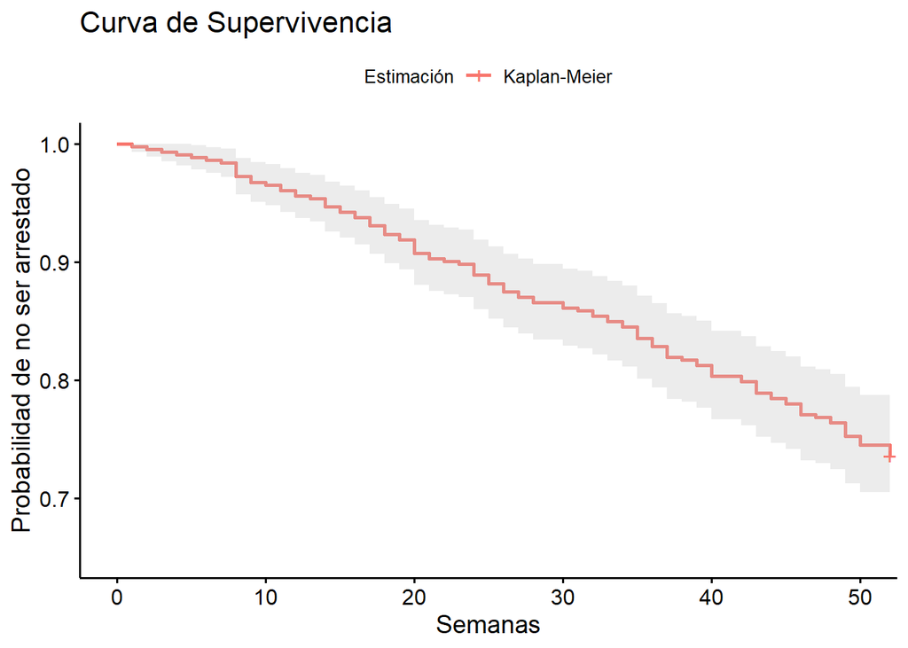

   ```r
   #KM
   km <- survfit(Surv(week, arrest) ~ 1,
                    type = "kaplan-meier",
                    data=data.rossi)

   ggsurvplot(fit = km,
              data =data.rossi,
              conf.int = TRUE,
              title = "Curva de Supervivencia",
              xlab = "Semanas",
              ylab = "Probabilidad de no ser arrestado",
              legend.title = "Estimación",
              legend.labs = "Kaplan-Meier",
              ylim = c(0.65,1))
   ```

   *Con el mismo objeto de sobrevivencia, usamos ggsurplot y la opción cumhaz:*
2. [10 puntos] Represente la función de riesgo acumulado no paramétrica de Nelson-Aalen.

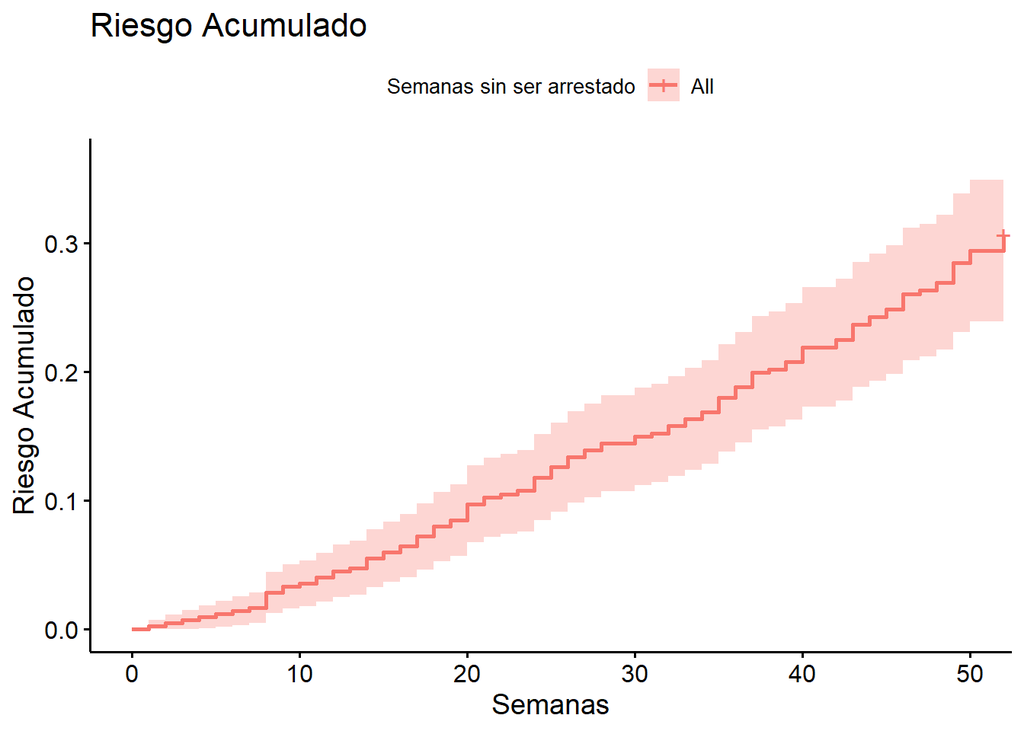

   ```r
   #Riesgo acumulado
   ggsurvplot(km,
              fun = "cumhaz",
              xlab = "Semanas",
              censor = T,
              ylab = "Riesgo Acumulado",
              title = "Riesgo Acumulado",
              legend.title = "Semanas sin ser arrestado")
   ```

3. [5 puntos] Represente nuevamente la función de sobrevivencia no paramétrica de Kaplan-Meier, pero ahora distinguiendo entre quienes recibieron y no recibieron ayuda del programa. ¿Qué observa?

   *Construimos primero el objeto de sobrevivencia por grupos de la variable fin. Luego procedemos exactamente igual:*

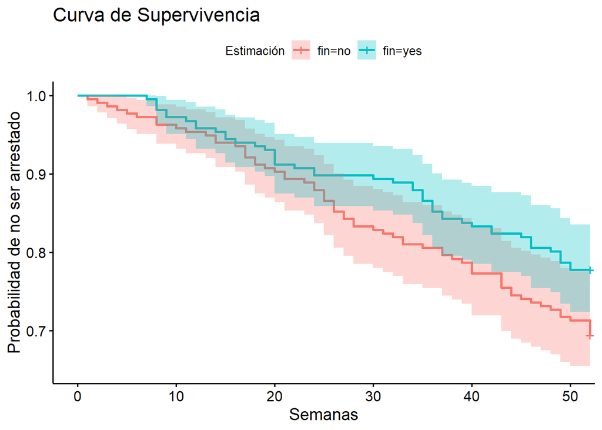

   ```r
   km.t <- survfit(Surv(week, arrest) ~ fin,
                    type = "kaplan-meier",
                    data=data.rossi)

   ggsurvplot(fit = km.t,
              data =data.rossi,
              conf.int = TRUE,
              title = "Curva de Supervivencia",
              xlab = "Semanas",
              ylab = "Probabilidad de no ser arrestado",
              legend.title = "Estimación",
              ylim = c(0.65,1))
   ```

   *Parece ser que los individuos que recibieron ayuda financiera tienen una mayor probabilidad de no volver a ser arrestado (la curva verder está por encima de la roja). Aunque los intervalos de confianza se traslapan.*
4. [10 puntos] Estime ahora un modelo paramátrico de duración asumiendo una distribución Weibull. ¿Cómo cambia la tasa de riesgo cuando la edad se incrementa en un año? Recuerde la expresión para este cambio en el caso Weibull que vimos en la [clase 22](https://ecnii-2021.netlify.app/clases/clase_22.html#24).

   **Muy importante antes de que interprete los coeficientes**: note que en el paquete *survival* usa una parametrización de la distribución Weibull diferente a la que se presenta en Cameron y Trivedi (2005) y otros textos de economía. En particular, en clase vimos que con la parametrización Weibull, las funciones de riesgo y sobrevivencia son:

   $$\lambda(t)=\gamma \alpha t^{\alpha-1}$$

   $$S(t)=exp(-\Lambda(t))=exp(-\gamma t^{\alpha})$$

   A $\alpha$ se le conoce como parámetro de escala, mientras que $\gamma$ es la media. En cambio, en el paquete *survival* el parámetro de escala es $\sigma=\frac{1}{\alpha}$, y se hace $\mu/\sigma=-\ln \gamma$. Por tanto,

   $$\lambda^*(t)=exp\left(-\frac{\mu}{\sigma}\right) \frac{1}{\sigma} t^{\frac{1}{\sigma}-1}$$
   $$S^*(t)=exp\left(-exp\left(-\frac{\mu}{\sigma}\right)t^{\frac{1}{\sigma}}\right)$$
   Esto implica que tenemos que *traducir* nuestros coeficientes estimados a la parametrización más natural, como en Cameron y Trivedi (2005), para poderlos interpretar. Basta entonces con calcular:

   $$\hat{\beta}_j=-\frac{\hat{\beta}_j^*}{\hat{\sigma}}$$
   donde $\hat{\beta}_j^*$ es el coeficiente estimado con *survival* y $\hat{\beta}_j$ es su contraparte asociada a la parametrización Weibull de Cameron y Trivedi (2005). Noten que $\hat{\sigma}$ es lo que la salida de la función *survreg* llama *Scale*. Podría hacer la transformación a mano, sin embargo, nos interesan también los errores estándar.

   Para hacer más práctica la transformación de los coeficientes Weibull use la función *ConvertWeibull* del paquete *SurvRegCensCov*. Esta función convierte los coeficientes a la parametrizaición Weibull más usada en economía, como la presentan Cameron y Trivedi (2005), y emplea el método delta para construir los errores estándar e intervalos de confianza. Ahora sí, puede interpretar los coeficientes de la regresión Weibull.

   *Estimamos la regresión Weibull y luego convertimos los coeficientes estimados a la parametrización vista en clase:*

   ```r
   sreg <- survreg(Surv(week, arrest) ~ fin + age + race + wexp + mar + paro + prio,
                   data=data.rossi,
                   dist = "weibull")

   ConvertWeibull(sreg, conf.level = 0.95)
   ```

   ```
   ## $vars
   ##                    Estimate          SE
   ## lambda          0.003272137 0.002755265
   ## gamma           1.403695274 0.124966345
   ## finyes         -0.382034422 0.191401535
   ## age            -0.057149766 0.021984492
   ## raceother      -0.315554127 0.307975363
   ## wexpyes        -0.149572978 0.212326830
   ## marnot married  0.436932811 0.381906391
   ## paroyes        -0.082575536 0.195865820
   ## prio            0.092386878 0.028735335
   ##
   ## $HR
   ##                       HR        LB        UB
   ## finyes         0.6824716 0.4689897 0.9931294
   ## age            0.9444526 0.9046216 0.9860374
   ## raceother      0.7293846 0.3988481 1.3338460
   ## wexpyes        0.8610756 0.5679477 1.3054920
   ## marnot married 1.5479521 0.7322817 3.2721772
   ## paroyes        0.9207419 0.6272153 1.3516342
   ## prio           1.0967891 1.0367249 1.1603331
   ##
   ## $ETR
   ##                      ETR        LB        UB
   ## finyes         1.3128014 1.0017645 1.7204119
   ## age            1.0415540 1.0093912 1.0747415
   ## raceother      1.2520753 0.8132627 1.9276583
   ## wexpyes        1.1124409 0.8265803 1.4971622
   ## marnot married 0.7325137 0.4287266 1.2515581
   ## paroyes        1.0605920 0.8066554 1.3944683
   ## prio           0.9363023 0.8986518 0.9755302
   ```

   *Con la conversión, tenemos los efectos estimados con la parametrización vista en clase. Entonces sabemos que:*

   $$\frac{d \lambda(t)}{d\enspace edad}=\lambda(t)\beta_{edad}$$

   *Es decir, en el modelo Weibull, los coeficientes tienen una interpretación de multiplicador del riesgo. En este caso, un año más de edad reduce el riesgo e incrementa la duración.*